# Text Analysis and Spatial Data for Economists

Assignment 1

zitian wang

25 March, 2025

```r
# Load first the libraries you will need
library(sf)
library(readr)
library(ggplot2)
library(dplyr)
library(leaflet)
library(RColorBrewer)
```

# Spatial operations

For this exercise, we will need first to import the file `swissBOUNDARIES3D_1_5_TLM_HOHEITSGEBIET.shp` containing the municipality boundary (do not use the file `swissBOUNDARIES3D_1_5_TLM_HOHEITSGRENZE.shp`) and the `.csv` file on housing price we used in the last exercise session.

To avoid issues with this exercise, you should remove the `Z` geometry (altitude of the point) of your municipality boundary object using the function `st_zm(your municipality object, drop = TRUE)`. Do not forget to save this as a new object.

```r
municipality <- st_read("/Users/zitian/Downloads/swissboundaries3d_2025-01_2056_5728.shp/swissBOUNDARIES3D_1_5_TLM_HOHEITSGEBIET.shp")
housing_data <- read_csv("/Users/zitian/Downloads/hp_small.csv")
municipality <- st_zm(municipality, drop = TRUE)
```

## Simplification

The municipality boundary contains a detailed (hence precise) geometry but uses a lot of memory such that you might want to simplify it first.

In also contains several variables that might not be directly of use.

- Look at the object size using `object.size()`
- Look at the structure of the object. Could you guess which attributes might not be useful?
  - select only the attributes related to the name of the municipality (‘NAME’), its population (‘EINWOHNERZ’), area (‘GEM_FLAECH’), identification number (‘BFS_NUMMER’) and the canton (‘KANTONSNUM’).

```r
print(object.size(municipality), units = "Mb")
```

```
## 23.1 Mb
```

```r
str(municipality)
```

```
## Classes 'sf' and 'data.frame':   2147 obs. of  24 variables:
##  $ UUID      : chr  "{5D7E5812-120E-491A-BFCD-CCED809316F4}" "{72947F82-8AB3-4334-AFC5-08B4FB50FEFC}" "{D0755E75-03C7-4185-B46C-26A6C46239BB}" "{993CEB7E-AF34-4056-916D-B4D5D3233716}" ...
##  $ DATUM_AEND: Date, format: "2024-10-18" "2024-10-18" ...
##  $ DATUM_ERST: Date, format: "2008-11-24" "2008-11-24" ...
##  $ ERSTELL_J : num  1997 2000 2006 2000 1997 ...
##  $ ERSTELL_M : chr  "1" "1" "1" "1" ...
##  $ GRUND_AEND: chr  "Verbessert" "Verbessert" "Verbessert" "Verbessert" ...
##  $ HERKUNFT  : chr  "swisstopo" "swisstopo" "swisstopo" "swisstopo" ...
##  $ HERKUNFT_J: num  2025 2025 2025 2025 2025 ...
##  $ HERKUNFT_M: chr  "1" "1" "1" "1" ...
##  $ REVISION_J: num  2025 2025 2025 2025 2025 ...
##  $ REVISION_M: chr  "1" "1" "1" "1" ...
##  $ REVISION_Q: chr  "TGMG_2025_Akt" "TGMG_2025_Akt" "TGMG_2025_Akt" "TGMG_2025_Akt" ...
##  $ OBJEKTART : chr  "Gemeindegebiet" "Gemeindegebiet" "Gemeindegebiet" "Gemeindegebiet" ...
##  $ BFS_NUMMER: num  131 3714 5722 6730 4123 ...
```

[output cut: 16 more lines]

```r
municipality_select <- municipality[, c("NAME", "EINWOHNERZ", "GEM_FLAECH", "BFS_NUMMER", "KANTONSNUM")]
```

- Simplify the geometry using your preferred simplification method.
  - Check the CRS of the data first and the units of measure.
  - Save your preferred result in a new object (e.g. ‘mun_simple’)

```r
print(st_crs(municipality_select))
```

```
## Coordinate Reference System:
##   User input: CH1903+ / LV95 + LN02 height
##   wkt:
## COMPOUNDCRS["CH1903+ / LV95 + LN02 height",
##     PROJCRS["CH1903+ / LV95",
##         BASEGEOGCRS["CH1903+",
##             DATUM["CH1903+",
##                 ELLIPSOID["Bessel 1841",6377397.155,299.1528128,
##                     LENGTHUNIT["metre",1]]],
##             PRIMEM["Greenwich",0,
##                 ANGLEUNIT["degree",0.0174532925199433]],
##             ID["EPSG",4150]],
##         CONVERSION["Swiss Oblique Mercator 1995",
##             METHOD["Hotine Oblique Mercator (variant B)",
##                 ID["EPSG",9815]],
##             PARAMETER["Latitude of projection centre",46.9524055555556,
##                 ANGLEUNIT["degree",0.0174532925199433],
##                 ID["EPSG",8811]],
##             PARAMETER["Longitude of projection centre",7.43958333333333,
##                 ANGLEUNIT["degree",0.0174532925199433],
##                 ID["EPSG",8812]],
##             PARAMETER["Azimuth at projection centre",90,
##                 ANGLEUNIT["degree",0.0174532925199433],
##                 ID["EPSG",8813]],
##             PARAMETER["Angle from Rectified to Skew Grid",90,
##                 ANGLEUNIT["degree",0.0174532925199433],
##                 ID["EPSG",8814]],
##             PARAMETER["Scale factor at projection centre",1,
##                 SCALEUNIT["unity",1],
##                 ID["EPSG",8815]],
##             PARAMETER["Easting at projection centre",2600000,
##                 LENGTHUNIT["metre",1],
##                 ID["EPSG",8816]],
##             PARAMETER["Northing at projection centre",1200000,
##                 LENGTHUNIT["metre",1],
##                 ID["EPSG",8817]]],
##         CS[Cartesian,2],
##             AXIS["(E)",east,
##                 ORDER[1],
##                 LENGTHUNIT["metre",1]],
##             AXIS["(N)",north,
##                 ORDER[2],
##                 LENGTHUNIT["metre",1]],
##         USAGE[
##             SCOPE["Cadastre, engineering survey, topographic mapping (large and medium scale)."],
##             AREA["Liechtenstein; Switzerland."],
##             BBOX[45.82,5.96,47.81,10.49]],
##         ID["EPSG",2056]],
##     VERTCRS["LN02 height",
##         VDATUM["Landesnivellement 1902"],
##         CS[vertical,1],
##             AXIS["gravity-related height (H)",up,
##                 LENGTHUNIT["metre",1]],
##         USAGE[
##             SCOPE["Engineering survey, topographic mapping."],
##             AREA["Liechtenstein; Switzerland."],
##             BBOX[45.82,5.96,47.81,10.49]],
##         ID["EPSG",5728]]]
```

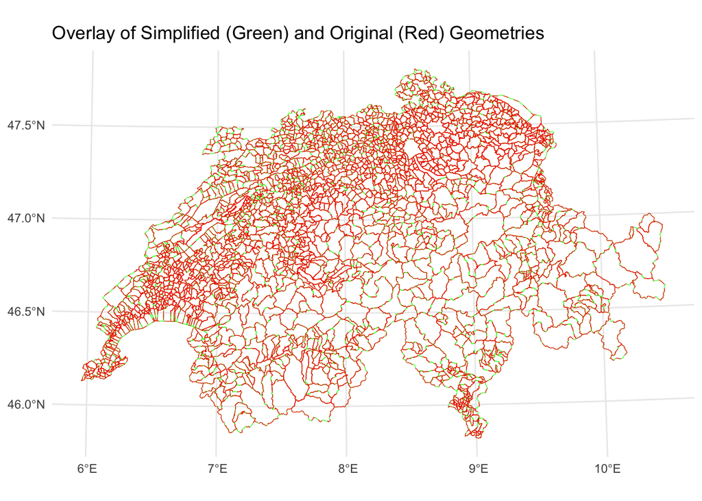

```r
mun_simple <- st_simplify(municipality_select, dTolerance = 50)

# Visualize overlay of simplified (green) and original (red dashed) geometries
ggplot() +
  geom_sf(data = mun_simple, fill = NA, color = "green", size = 0.5) +
  geom_sf(data = municipality_select, fill = NA, color = "red", size = 1.5, linetype = "dashed", alpha = 0.8) +
  labs(title = "Overlay of Simplified (Green) and Original (Red) Geometries") +
  theme_minimal()
```

## Spatial join

We would like now to compute the average housing price for all Swiss municipalities. To avoid outliers, we prefer to select only municipalities with at least 5 postings.

- Create a logical vector that identifies all municipalities with at least 5 postings.
  - What should you do first?
  - Which municipality object should you use, the original or the simplified one? Why?

```r
# Use CSV field 'bfscode1' to represent municipality identifier
posting_counts <- table(housing_data$bfscode1)
municipalities_with5 <- names(posting_counts)[posting_counts >= 5]
print(municipalities_with5)
```

```
##   [1] "2"    "3"    "10"   "13"   "51"   "52"   "53"   "54"   "55"   "56"
##  [11] "58"   "62"   "64"   "66"   "69"   "72"   "83"   "84"   "86"   "88"
##  [21] "89"   "90"   "92"   "96"   "97"   "101"  "111"  "112"  "113"  "115"
##  [31] "117"  "118"  "120"  "121"  "131"  "135"  "136"  "137"  "138"  "139"
##  [41] "141"  "151"  "152"  "153"  "154"  "155"  "156"  "157"  "158"  "159"
##  [51] "160"  "161"  "172"  "177"  "181"  "191"  "192"  "193"  "194"  "195"
##  [61] "198"  "199"  "200"  "223"  "224"  "227"  "230"  "231"  "242"  "243"
##  [71] "244"  "245"  "247"  "250"  "251"  "261"  "293"  "295"  "296"  "298"
##  [81] "301"  "306"  "311"  "321"  "329"  "351"  "352"  "355"  "356"  "361"
##  [91] "362"  "363"  "371"  "392"  "404"  "443"  "446"  "538"  "540"  "544"
## [101] "546"  "551"  "552"  "608"  "616"  "627"  "667"  "670"  "700"  "733"
## [111] "739"  "743"  "745"  "755"  "768"  "861"  "902"  "928"  "934"  "939"
## [121] "942"  "954"  "979"  "1024" "1030" "1031" "1040" "1052" "1054" "1058"
## [131] "1059" "1061" "1062" "1063" "1065" "1069" "1081" "1093" "1098" "1103"
## [141] "1104" "1128" "1139" "1140" "1143" "1151" "1201" "1206" "1301" "1321"
```

[output cut: 29 more lines]

## Spatial subsetting

- Create an object containing only municipalities with at least 5 postings.

```r
# Municipality data uses BFS_NUMMER while CSV uses bfscode1.
mun5 <- mun_simple[mun_simple$BFS_NUMMER %in% municipalities_with5, ]
```

## Spatial aggregation

- Compute the annual rental price per square meter (a_brutm_m2) per municipality (use the variable BFS_NUMMER to identify them) with at least 5 observations. First convert the variable a_brutm_m2 to numeric with, e.g., the function `type.convert(x, dec=".")`.

```r
# Convert rental price per square meter to numeric
housing_data$a_brutm_m2 <- type.convert(housing_data$a_brutm_m2, dec = ".")
# Aggregate average rental price by municipality identifier (using bfscode1 from CSV)
avg_price <- aggregate(a_brutm_m2 ~ bfscode1,
                       data = housing_data[housing_data$bfscode1 %in% municipalities_with5, ],
                       FUN = mean)
head(avg_price)
```

```
##   bfscode1 a_brutm_m2
## 1        2   247.7100
## 2        3   211.6366
## 3       10   212.5000
## 4       13   233.0397
## 5       51   263.2013
## 6       52   255.6250
```

- Plot these municipalities

```r
# Municipality data uses BFS_NUMMER while CSV uses bfscode1.
mun5 <- mun_simple[mun_simple$BFS_NUMMER %in% municipalities_with5, ]

# Merge the aggregated average price (avg_price) with the spatial object.
mun5_prices_agg <- merge(mun5, avg_price, by.x = "BFS_NUMMER", by.y = "bfscode1", all.x = TRUE)

# Transform to WGS84 for leaflet (EPSG:4326)
mun5_prices_agg_wgs <- st_transform(mun5_prices_agg, crs = 4326)

# Define a color palette based on average rental price.
pal <- colorQuantile("YlOrRd", domain = mun5_prices_agg_wgs$a_brutm_m2, n = 5)
```

```r
# Create an interactive leaflet map.
leaflet(data = mun5_prices_agg_wgs) %>%
  addProviderTiles(providers$CartoDB.Positron) %>%
  addPolygons(
    fillColor = ~pal(a_brutm_m2),
    fillOpacity = 0.7,
    weight = 1,
    color = "darkblue",
    popup = ~paste0("<strong>Municipality: </strong>", NAME,
                    "<br><strong>BFS: </strong>", BFS_NUMMER,
                    "<br><strong>Price (per m²): </strong>", round(a_brutm_m2, 2))
  ) %>%
  setView(lng = 8.2275, lat = 46.8182, zoom = 8)
```

[interactive chart not shown]

- Add to this object the corresponding housing prices

```r
# Merge detailed housing data with spatial data (if needed for further analysis)
mun5_prices <- merge(mun5, housing_data, by.x = "BFS_NUMMER", by.y = "bfscode1", all.x = TRUE)
str(mun5_prices)
```

```
## Classes 'sf' and 'data.frame':   8387 obs. of  21 variables:
##  $ BFS_NUMMER      : num  2 2 2 2 2 2 2 2 2 2 ...
##  $ NAME            : chr  "Affoltern am Albis" "Affoltern am Albis" "Affoltern am Albis" "Affoltern am Albis" ...
##  $ EINWOHNERZ      : num  12859 12859 12859 12859 12859 ...
##  $ GEM_FLAECH      : num  1059 1059 1059 1059 1059 ...
##  $ KANTONSNUM      : num  1 1 1 1 1 1 1 1 1 1 ...
##  $ kennummer       : num  2756049 6981962 1868807 1800387 2684344 ...
##  $ a_kat_o_2       : chr  "AP" "AP" "AP" "HO" ...
##  $ a_zip_2         : num  8910 8910 8910 8910 8910 ...
##  $ a_street        : chr  "LICHTMATTSTRASSE" "ZUERICHSTRASSE" "BREITENWEG" "GIESSENSTRASSE" ...
##  $ a_hausnr        : chr  "11" "169" "8" "5A" ...
##  $ a_surface_living: num  112 80 90 105 114 160 125 60 63 72 ...
##  $ a_brutm_mon     : num  NA 1655 1591 1780 1730 ...
##  $ a_brutm_m2      : num  NA 248 212 203 182 ...
##  $ a_nb_rooms      : num  3.5 3.5 4.5 4.5 3.5 ...
##  $ a_floor         : num  3 2 3 2 2 ...
##  $ a_baup          : num  2005 9999 1960 1980 1980 ...
##  $ g_day           : num  20100331 20150409 20080423 20080109 20100317 ...
##  $ g_fin           : num  20100606 20150416 20080513 20080324 20100319 ...
##  $ latitude2       : num  47.3 47.3 47.3 47.3 47.3 ...
##  $ longitude2      : num  8.45 8.45 8.45 8.45 8.45 ...
##  $ geometry        :sfc_GEOMETRY of length 8387; first list element: List of 1
##   ..$ : num [1:83, 1:2] 2673826 2674132 2674355 2674911 2675007 ...
##   ..- attr(*, "class")= chr [1:3] "XY" "POLYGON" "sfg"
##  - attr(*, "sf_column")= chr "geometry"
##  - attr(*, "agr")= Factor w/ 3 levels "constant","aggregate",..: NA NA NA NA NA NA NA NA NA NA ...
##   ..- attr(*, "names")= chr [1:20] "BFS_NUMMER" "NAME" "EINWOHNERZ" "GEM_FLAECH" ...
```

- Plot the average housing price per square meter

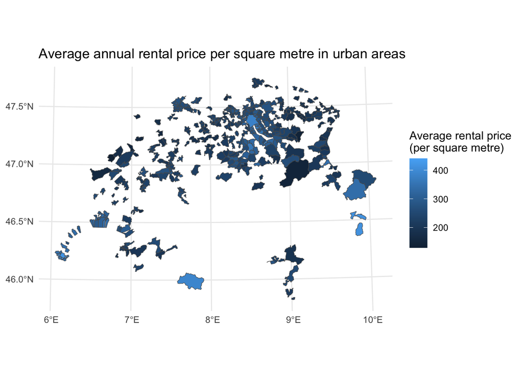

```r
ggplot(mun5_prices_agg) +
  geom_sf(aes(fill = a_brutm_m2)) +
  labs(fill = "Average rental price\n(per square metre)") +
  ggtitle("Average annual rental price per square metre in urban areas") +
  theme_minimal()
```

## Distances

Select all postings in the canton of Ticino that are located within a 1km distance of a municipality border

- How would you approach this problem?
- What information do you need?
- **Think carefully at how distance are computed for different geometries**
- Before doing any analysis, you should remove the `Z` geometry (altitude of the point) using the function `st_zm(your municipality object, drop = TRUE)`

```r
housing_sf <- st_as_sf(housing_data, coords = c("longitude2", "latitude2"), crs = 4326)

housing_sf <- st_transform(housing_sf, st_crs(mun_simple))

mun_ti <- mun_simple[mun_simple$KANTONSNUM == 21, ]
mun_ti_clean <- st_cast(mun_ti, "MULTIPOLYGON", warn = FALSE)

ti_boundaries <- st_boundary(mun_ti_clean)
ti_boundaries_union <- st_union(ti_boundaries)

distances <- st_distance(housing_sf, ti_boundaries_union)
min_distances <- as.numeric(distances)

print(summary(min_distances))
```

```
##      Min.   1st Qu.    Median      Mean   3rd Qu.      Max.
##      4.59  83548.29  94663.64  97081.67 114126.98 187122.56
```

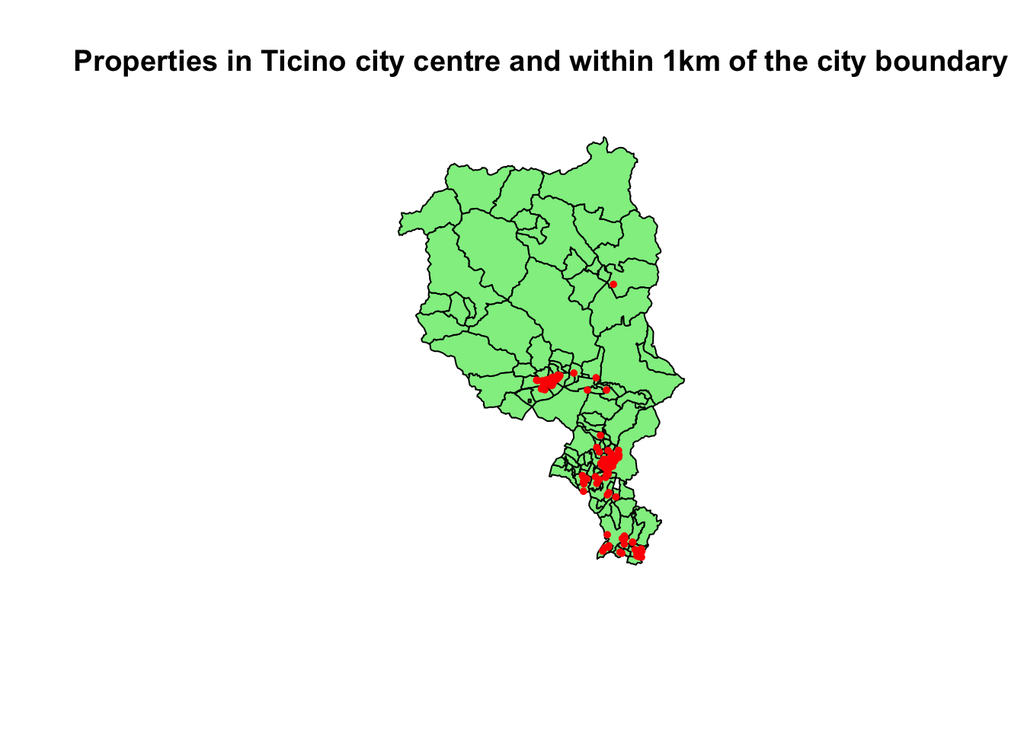

```r
housing_near_border <- housing_sf[min_distances <= 1000, ]

plot(st_geometry(mun_ti_clean), main = "Properties in Ticino city centre and within 1km of the city boundary", col = "lightgreen")
plot(st_geometry(housing_near_border), add = TRUE, col = "red", pch = 20, cex=0.8)
```